# Экологические установки и ситуативные стимулы в условиях трансформирующейся экологической культуры России: эмпирическое исследование

# Введение

Оцениваются 4 поведенческих блока:

- Переработка (Recycling Behavior, RB),
- Эко-покупки (Eco-Shopping Behavior, ESB),
- Ресурсосбережение (Resource-Saving Behavior, RSB),
- Эко-мобильность (Eco-Mobility Behavior, EMB).

По каждому из блоков считается аддитивный индекс, представляющий собой оценку склонности респондента к определённому виду эко-поведения. Дополнительно считается индекс склонности к комфорту против склонности к экономии (tendency to be comfortable, TC).

## Гипотезы

*Гипотеза H1.* Эко-поведение не однородно - склонность к одному из видов эко-поведения не предопределяет склонность к другому.

*Гипотеза H2.* Люди обычно переоценивают собственную склонность к эко-поведению и недооценивают склонность окружающих.

*Гипотеза H3.* Склонность к тому или иному виду эко-поведения ситуативно подвержена влиянию стимулов, как эмоционального, так и рационального характера.

*Гипотеза H3а.* Склонность к более затратным видам поведения менее подвержена ситуативному влиянию стимулов (low-cost hypothesis).

## Подготовка данных

Ниже представленны параметры окружения R. Производится загрузка данных, логарифмирование некоторых признаков (возраст, размер города, время ответа). Вычисляются аддитивные индексы, затем производится их унификация в диапазоне [0…1] для удобства графического отображения и интерпретации.

```r
library(knitr)
library(MatchIt)
library(dplyr)
library(ggplot2)
library(ggthemes)
library(gplots)
library(gtable)
library(egg)
library(corrplot)
library(scales)
```

```r
#loading raw data
data<-read.csv("ecodata.csv", sep=";", dec=",")

data<-data[!is.na(data$age),]
data<-data[!is.na(data$income),]

data$group<-factor(data$group, labels = c("Control","Rational","Emotional"))

#log data
data$log_age <- log10(data$age)
data$log_city_size <- log10(data$city_size)
data$log_time_RB <- log10(data$time_12)
data$log_time_ESB <- log10(data$time_34)
data$log_time_RSB <- log10(data$time_56)
data$log_time_EMB <- log10(data$time_78)
data$log_time_TC <- log10(data$time_9)

#make an additive indexes
data$RB  <- (data$case_1_1 + data$case_1_2 + data$case_2_1 + data$case_2_2) #1..24
data$ESB <- (data$case_3_1 + data$case_3_2 + data$case_4_1 + data$case_4_2) #1..24
data$RSB <- (data$case_5_1 + data$case_5_2 + data$case_6_1 + data$case_6_2) #1..24
data$EMB <- (data$case_7_1 + data$case_7_2 + data$case_8_1 + data$case_8_2) #1..24

data<-data[!is.na(data$ESB),]

data$TC  <- (data$case_9_1 + data$case_9_2) #1..12

data$RBo  <- (data$case_1_3 + data$case_2_3) #1..12
data$ESBo <- (data$case_3_3 + data$case_4_3) #1..12
data$RSBo <- (data$case_5_3 + data$case_6_3) #1..12
data$EMBo <- (data$case_7_3 + data$case_8_3) #1..12


#rescale <- function(x){(x-min(x))/(max(x)-min(x))}

data$RB  <- rescale(data$RB)
data$ESB <- rescale(data$ESB)
data$RSB <- rescale(data$RSB)
data$EMB <- rescale(data$EMB)
data$TC  <- rescale(data$TC)
data$RBo  <- rescale(data$RBo)
data$ESBo <- rescale(data$ESBo)
data$RSBo <- rescale(data$RSBo)
data$EMBo <- rescale(data$EMBo)
```

## Сводные статистики и описание данных

```r
summary(data[,c(29,30,32:37,39, 54:62)])
```

```
##       emo              rat              sex              age
##  Min.   :0.0000   Min.   :0.0000   Min.   :0.0000   Min.   :14.00
##  1st Qu.:0.0000   1st Qu.:0.0000   1st Qu.:0.0000   1st Qu.:20.00
##  Median :0.0000   Median :0.0000   Median :0.0000   Median :26.00
##  Mean   :0.4977   Mean   :0.4859   Mean   :0.3354   Mean   :28.88
##  3rd Qu.:1.0000   3rd Qu.:1.0000   3rd Qu.:1.0000   3rd Qu.:35.00
##  Max.   :1.0000   Max.   :1.0000   Max.   :1.0000   Max.   :67.00
##  NA's   :103      NA's   :108      NA's   :1
##      income        isworking           edu             car
##  Min.   :1.000   Min.   :0.0000   Min.   :1.000   Min.   :0.0000
##  1st Qu.:1.000   1st Qu.:0.0000   1st Qu.:3.000   1st Qu.:0.0000
##  Median :2.000   Median :1.0000   Median :3.000   Median :1.0000
##  Mean   :2.366   Mean   :0.6509   Mean   :3.065   Mean   :0.7339
##  3rd Qu.:3.000   3rd Qu.:1.0000   3rd Qu.:3.000   3rd Qu.:1.0000
##  Max.   :5.000   Max.   :1.0000   Max.   :4.000   Max.   :1.0000
##                  NA's   :2        NA's   :196     NA's   :196
##    city_size              RB              ESB              RSB
##  Min.   :    2552   Min.   :0.0000   Min.   :0.0000   Min.   :0.0000
##  1st Qu.:  686430   1st Qu.:0.4500   1st Qu.:0.5000   1st Qu.:0.4000
##  Median : 1195446   Median :0.5500   Median :0.6500   Median :0.5000
##  Mean   : 2694228   Mean   :0.5858   Mean   :0.6252   Mean   :0.4959
##  3rd Qu.: 1483119   3rd Qu.:0.7500   3rd Qu.:0.7500   3rd Qu.:0.5500
##  Max.   :12692466   Max.   :1.0000   Max.   :1.0000   Max.   :1.0000
##  NA's   :17
##       EMB               TC              RBo              ESBo
##  Min.   :0.0000   Min.   :0.0000   Min.   :0.0000   Min.   :0.0000
##  1st Qu.:0.4875   1st Qu.:0.5000   1st Qu.:0.2000   1st Qu.:0.5000
##  Median :0.6000   Median :0.8000   Median :0.3000   Median :0.5000
##  Mean   :0.5837   Mean   :0.6937   Mean   :0.3197   Mean   :0.5197
##  3rd Qu.:0.7500   3rd Qu.:1.0000   3rd Qu.:0.5000   3rd Qu.:0.6000
##  Max.   :1.0000   Max.   :1.0000   Max.   :1.0000   Max.   :1.0000
##
##       RSBo             EMBo
##  Min.   :0.0000   Min.   :0.0000
##  1st Qu.:0.4000   1st Qu.:0.3000
##  Median :0.5000   Median :0.5000
##  Mean   :0.4928   Mean   :0.4259
##  3rd Qu.:0.6000   3rd Qu.:0.5000
##  Max.   :1.0000   Max.   :1.0000
##
```

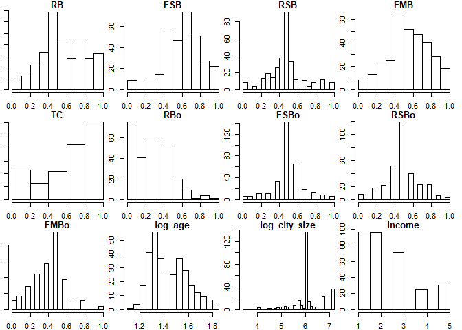

```r
par(mfrow = c(3,4), mar=c(2,1,1,1))
hist(data$RB, breaks = "FD", main = "RB")
hist(data$ESB, breaks = "FD", main = "ESB")
hist(data$RSB, breaks = "FD", main = "RSB")
hist(data$EMB, breaks = "FD", main = "EMB")
hist(data$TC, breaks = "FD", main = "TC")
hist(data$RBo, breaks = "FD", main = "RBo")
hist(data$ESBo, breaks = "FD", main = "ESBo")
hist(data$RSBo, breaks = "FD", main = "RSBo")
hist(data$EMBo, breaks = "FD", main = "EMBo")

hist(data$log_age, breaks = "FD", main = "log_age")
hist(data$log_city_size, breaks = "FD", main = "log_city_size")
hist(data$income, breaks = "FD", main = "income")
```

## Анализ различий между несбалансированными группами

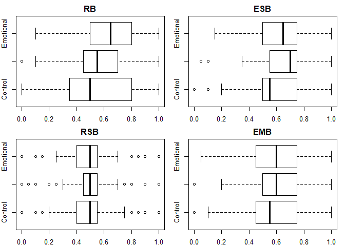

```r
par(mfrow = c(2,2), mar=c(2,2,2,1))
boxplot(RB ~ group, data=data, main="RB", horizontal = T)
boxplot(ESB ~ group, data=data, main="ESB", horizontal = T)
boxplot(RSB ~ group, data=data, main="RSB", horizontal = T)
boxplot(EMB ~ group, data=data, main="EMB", horizontal = T)
```

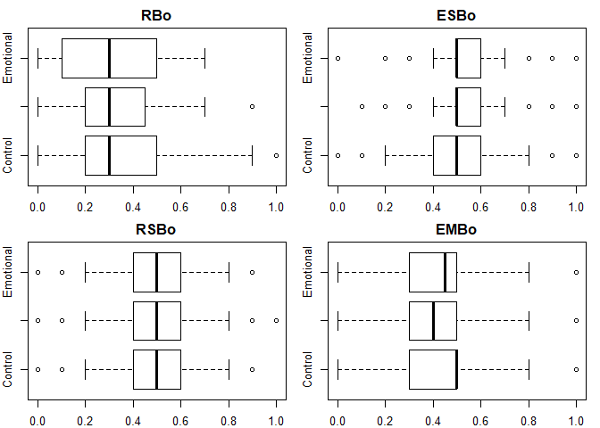

```r
boxplot(RBo ~ group, data=data, main="RBo", horizontal = T)
boxplot(ESBo ~ group, data=data, main="ESBo", horizontal = T)
boxplot(RSBo ~ group, data=data, main="RSBo", horizontal = T)
boxplot(EMBo ~ group, data=data, main="EMBo", horizontal = T)
```

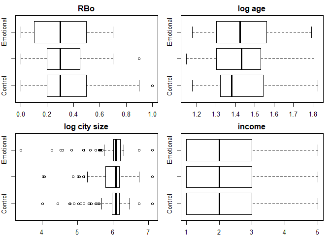

```r
boxplot(RBo ~ group, data=data, main="RBo", horizontal = T)

boxplot(log_age ~ group, data=data, main="log age", horizontal = T)
boxplot(log_city_size ~ group, data=data, main="log city size", horizontal = T)
boxplot(income ~ group, data=data, main="income", horizontal = T)
```

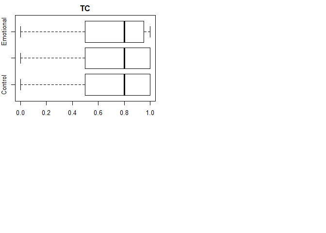

```r
boxplot(TC ~ group, data=data, main="TC", horizontal = T)
```

```r
summary(data[data$group=="Control",c(29,30,32:37,39, 54:62)])
```

```
##       emo         rat         sex              age            income
##  Min.   :0   Min.   :0   Min.   :0.0000   Min.   :15.00   Min.   :1.00
##  1st Qu.:0   1st Qu.:0   1st Qu.:0.0000   1st Qu.:21.00   1st Qu.:1.00
##  Median :0   Median :0   Median :0.0000   Median :24.00   Median :2.00
##  Mean   :0   Mean   :0   Mean   :0.3945   Mean   :28.35   Mean   :2.33
##  3rd Qu.:0   3rd Qu.:0   3rd Qu.:1.0000   3rd Qu.:35.00   3rd Qu.:3.00
##  Max.   :0   Max.   :0   Max.   :1.0000   Max.   :67.00   Max.   :5.00
##
##    isworking           edu             car           city_size
##  Min.   :0.0000   Min.   :1.000   Min.   :0.0000   Min.   :   10293
##  1st Qu.:0.0000   1st Qu.:3.000   1st Qu.:1.0000   1st Qu.:  952136
##  Median :1.0000   Median :3.000   Median :1.0000   Median : 1195446
##  Mean   :0.6389   Mean   :2.955   Mean   :0.8182   Mean   : 2904776
##  3rd Qu.:1.0000   3rd Qu.:3.000   3rd Qu.:1.0000   3rd Qu.: 1483119
##  Max.   :1.0000   Max.   :4.000   Max.   :1.0000   Max.   :12692466
##  NA's   :1        NA's   :65      NA's   :65       NA's   :3
##        RB              ESB              RSB              EMB
##  Min.   :0.0000   Min.   :0.0000   Min.   :0.0000   Min.   :0.0000
##  1st Qu.:0.3500   1st Qu.:0.5000   1st Qu.:0.4000   1st Qu.:0.4500
##  Median :0.5000   Median :0.5500   Median :0.5000   Median :0.5500
##  Mean   :0.5459   Mean   :0.5766   Mean   :0.4968   Mean   :0.5642
##  3rd Qu.:0.8000   3rd Qu.:0.7500   3rd Qu.:0.5500   3rd Qu.:0.7500
##  Max.   :1.0000   Max.   :1.0000   Max.   :1.0000   Max.   :1.0000
##
##        TC              RBo              ESBo             RSBo
##  Min.   :0.0000   Min.   :0.0000   Min.   :0.0000   Min.   :0.0000
##  1st Qu.:0.5000   1st Qu.:0.2000   1st Qu.:0.4000   1st Qu.:0.4000
##  Median :0.8000   Median :0.3000   Median :0.5000   Median :0.5000
##  Mean   :0.6982   Mean   :0.3431   Mean   :0.4927   Mean   :0.4991
##  3rd Qu.:1.0000   3rd Qu.:0.5000   3rd Qu.:0.6000   3rd Qu.:0.6000
##  Max.   :1.0000   Max.   :1.0000   Max.   :1.0000   Max.   :0.9000
##
##       EMBo
##  Min.   :0.0000
##  1st Qu.:0.3000
##  Median :0.5000
##  Mean   :0.4147
##  3rd Qu.:0.5000
##  Max.   :1.0000
##
```

```r
head(data[data$group=="Control",c(29,30,32:37,39, 54:62)])
```

```
##    emo rat sex age income isworking edu car city_size   RB  ESB  RSB  EMB  TC
## 2    0   0   1  18      1         0  NA  NA   1195446 0.00 0.00 0.00 0.00 0.0
## 3    0   0   0  22      2         1  NA  NA   1195446 0.80 0.50 0.55 0.55 1.0
## 4    0   0   0  30      3         1  NA  NA   1195446 0.55 0.95 0.60 0.45 0.8
## 7    0   0   1  35      5         1  NA  NA   1195446 0.40 0.85 0.85 0.75 0.4
## 13   0   0   1  22      2         0  NA  NA   1195446 0.45 0.35 0.30 0.20 0.2
## 22   0   0   0  19      1         0  NA  NA   1195446 0.75 0.50 0.70 1.00 0.6
##    RBo ESBo RSBo EMBo
## 2  0.0  0.0  0.0  0.0
## 3  0.5  0.5  0.5  0.5
## 4  0.4  0.6  0.5  0.4
## 7  0.5  0.6  0.8  0.3
## 13 0.7  0.9  0.4  0.3
## 22 0.3  0.5  0.4  0.8
```

```r
nrow(data[data$group=="Control",c(29,30,32:37,39, 54:62)])
```

```
## [1] 109
```

```r
summary(data[data$group=="Emotional",c(29,30,32:37,39, 54:62)])
```

```
##       emo         rat           sex              age            income
##  Min.   :1   Min.   : NA   Min.   :0.0000   Min.   :15.00   Min.   :1.000
##  1st Qu.:1   1st Qu.: NA   1st Qu.:0.0000   1st Qu.:20.00   1st Qu.:1.000
##  Median :1   Median : NA   Median :0.0000   Median :26.50   Median :2.000
##  Mean   :1   Mean   :NaN   Mean   :0.2685   Mean   :29.29   Mean   :2.546
##  3rd Qu.:1   3rd Qu.: NA   3rd Qu.:1.0000   3rd Qu.:36.25   3rd Qu.:3.000
##  Max.   :1   Max.   : NA   Max.   :1.0000   Max.   :62.00   Max.   :5.000
##              NA's   :108
##    isworking           edu             car           city_size
##  Min.   :0.0000   Min.   :1.000   Min.   :0.0000   Min.   :    2552
##  1st Qu.:0.0000   1st Qu.:3.000   1st Qu.:0.0000   1st Qu.: 1013468
##  Median :1.0000   Median :3.000   Median :1.0000   Median : 1195446
##  Mean   :0.6822   Mean   :3.171   Mean   :0.7073   Mean   : 2746519
##  3rd Qu.:1.0000   3rd Qu.:3.000   3rd Qu.:1.0000   3rd Qu.: 1618039
##  Max.   :1.0000   Max.   :4.000   Max.   :1.0000   Max.   :12692466
##  NA's   :1        NA's   :67      NA's   :67       NA's   :3
##        RB              ESB              RSB              EMB
##  Min.   :0.1000   Min.   :0.1500   Min.   :0.0000   Min.   :0.0500
##  1st Qu.:0.5000   1st Qu.:0.5000   1st Qu.:0.4000   1st Qu.:0.4500
##  Median :0.6500   Median :0.6500   Median :0.5000   Median :0.6000
##  Mean   :0.6356   Mean   :0.6343   Mean   :0.4921   Mean   :0.5769
##  3rd Qu.:0.8000   3rd Qu.:0.7500   3rd Qu.:0.5500   3rd Qu.:0.7500
##  Max.   :1.0000   Max.   :1.0000   Max.   :1.0000   Max.   :1.0000
##
##        TC              RBo              ESBo            RSBo
##  Min.   :0.0000   Min.   :0.0000   Min.   :0.000   Min.   :0.0000
##  1st Qu.:0.5000   1st Qu.:0.1000   1st Qu.:0.500   1st Qu.:0.4000
##  Median :0.8000   Median :0.3000   Median :0.500   Median :0.5000
##  Mean   :0.6963   Mean   :0.3009   Mean   :0.538   Mean   :0.4639
##  3rd Qu.:0.9250   3rd Qu.:0.5000   3rd Qu.:0.600   3rd Qu.:0.6000
##  Max.   :1.0000   Max.   :0.7000   Max.   :1.000   Max.   :0.9000
##
##       EMBo
##  Min.   :0.000
##  1st Qu.:0.300
##  Median :0.450
##  Mean   :0.437
##  3rd Qu.:0.500
##  Max.   :1.000
##
```

```r
head(data[data$group=="Emotional",c(29,30,32:37,39, 54:62)])
```

```
##    emo rat sex age income isworking edu car city_size   RB  ESB  RSB  EMB  TC
## 1    1  NA   0  34      3         1  NA  NA   1195446 0.75 0.50 0.45 0.65 0.7
## 5    1  NA   0  34      3         1  NA  NA   1195446 0.75 0.55 0.45 0.75 0.9
## 6    1  NA   0  25      2         1  NA  NA  12692466 1.00 0.15 0.45 0.70 1.0
## 12   1  NA   0  19      1         0  NA  NA   1195446 0.90 0.45 0.35 0.95 0.8
## 14   1  NA   0  24      1         0  NA  NA   1195446 0.80 0.15 0.50 0.10 0.0
## 15   1  NA   0  17      1         0  NA  NA    151275 0.90 0.65 0.50 0.80 1.0
##    RBo ESBo RSBo EMBo
## 1  0.6  0.5  0.4  0.5
## 5  0.5  0.6  0.5  0.4
## 6  0.1  0.9  0.5  0.3
## 12 0.0  1.0  0.1  0.2
## 14 0.3  0.4  0.5  0.6
## 15 0.0  0.5  0.5  0.0
```

```r
nrow(data[data$group=="Emotional",c(29,30,32:37,39, 54:62)])
```

```
## [1] 108
```

```r
summary(data[data$group=="Rational",c(29,30,32:37,39, 54:62)])
```

```
##       emo           rat         sex              age            income
##  Min.   : NA   Min.   :1   Min.   :0.0000   Min.   :14.00   Min.   :1.000
##  1st Qu.: NA   1st Qu.:1   1st Qu.:0.0000   1st Qu.:20.00   1st Qu.:1.000
##  Median : NA   Median :1   Median :0.0000   Median :27.00   Median :2.000
##  Mean   :NaN   Mean   :1   Mean   :0.3431   Mean   :29.02   Mean   :2.214
##  3rd Qu.: NA   3rd Qu.:1   3rd Qu.:1.0000   3rd Qu.:34.00   3rd Qu.:3.000
##  Max.   : NA   Max.   :1   Max.   :1.0000   Max.   :64.00   Max.   :5.000
##  NA's   :103               NA's   :1
##    isworking           edu             car           city_size
##  Min.   :0.0000   Min.   :1.000   Min.   :0.0000   Min.   :   10854
##  1st Qu.:0.0000   1st Qu.:3.000   1st Qu.:0.0000   1st Qu.:  614367
##  Median :1.0000   Median :3.000   Median :1.0000   Median : 1195446
##  Mean   :0.6311   Mean   :3.077   Mean   :0.6667   Mean   : 2391960
##  3rd Qu.:1.0000   3rd Qu.:3.000   3rd Qu.:1.0000   3rd Qu.: 1483119
##  Max.   :1.0000   Max.   :4.000   Max.   :1.0000   Max.   :12692466
##                   NA's   :64      NA's   :64       NA's   :11
##        RB              ESB             RSB             EMB
##  Min.   :0.0000   Min.   :0.050   Min.   :0.000   Min.   :0.0000
##  1st Qu.:0.4500   1st Qu.:0.550   1st Qu.:0.450   1st Qu.:0.5000
##  Median :0.5500   Median :0.700   Median :0.500   Median :0.6000
##  Mean   :0.5757   Mean   :0.667   Mean   :0.499   Mean   :0.6117
##  3rd Qu.:0.7000   3rd Qu.:0.750   3rd Qu.:0.550   3rd Qu.:0.7500
##  Max.   :1.0000   Max.   :1.000   Max.   :1.000   Max.   :1.0000
##
##        TC              RBo              ESBo             RSBo
##  Min.   :0.0000   Min.   :0.0000   Min.   :0.1000   Min.   :0.0000
##  1st Qu.:0.5000   1st Qu.:0.2000   1st Qu.:0.5000   1st Qu.:0.4000
##  Median :0.8000   Median :0.3000   Median :0.5000   Median :0.5000
##  Mean   :0.6864   Mean   :0.3146   Mean   :0.5291   Mean   :0.5165
##  3rd Qu.:1.0000   3rd Qu.:0.4500   3rd Qu.:0.6000   3rd Qu.:0.6000
##  Max.   :1.0000   Max.   :0.9000   Max.   :1.0000   Max.   :1.0000
##
##       EMBo
##  Min.   :0.0000
##  1st Qu.:0.3000
##  Median :0.4000
##  Mean   :0.4262
##  3rd Qu.:0.5000
##  Max.   :1.0000
##
```

```r
head(data[data$group=="Rational",c(29,30,32:37,39, 54:62)])
```

```
##    emo rat sex age income isworking edu car city_size   RB  ESB RSB EMB  TC RBo
## 9   NA   1   0  59      5         0  NA  NA        NA 0.50 0.50 0.5 0.5 0.0 0.0
## 18  NA   1   0  22      1         0  NA  NA   1195446 0.45 0.55 0.5 0.4 0.6 0.5
## 19  NA   1   0  20      1         0  NA  NA   1195446 0.15 0.70 0.2 0.5 0.2 0.2
## 25  NA   1   0  23      2         1  NA  NA   1195446 0.60 0.60 0.3 0.7 0.0 0.1
## 30  NA   1   0  27      3         1  NA  NA   5392992 0.70 0.50 0.5 0.5 0.9 0.2
## 38  NA   1   1  32      3         1  NA  NA   1195446 0.45 0.65 0.1 0.4 0.2 0.5
##    ESBo RSBo EMBo
## 9   0.5  0.5  0.5
## 18  0.6  0.6  0.5
## 19  0.5  0.4  0.7
## 25  0.5  0.5  0.4
## 30  0.5  0.5  0.5
## 38  0.4  0.1  0.1
```

```r
nrow(data[data$group=="Rational",c(29,30,32:37,39, 54:62)])
```

```
## [1] 103
```

```r
library(psych)
describeBy(data[,c(32:37,39,54:62)], data$group, na.rm = T)$Control[,c(2:5,8,9)]
```

```
##             n       mean         sd     median   min        max
## sex       109       0.39       0.49       0.00     0        1.0
## age       109      28.35      10.37      24.00    15       67.0
## income    109       2.33       1.24       2.00     1        5.0
## isworking 108       0.64       0.48       1.00     0        1.0
## edu        44       2.95       0.68       3.00     1        4.0
## car        44       0.82       0.39       1.00     0        1.0
## city_size 106 2904776.10 4255889.26 1195446.00 10293 12692466.0
## RB        109       0.55       0.28       0.50     0        1.0
## ESB       109       0.58       0.23       0.55     0        1.0
## RSB       109       0.50       0.19       0.50     0        1.0
## EMB       109       0.56       0.24       0.55     0        1.0
## TC        109       0.70       0.32       0.80     0        1.0
## RBo       109       0.34       0.21       0.30     0        1.0
## ESBo      109       0.49       0.19       0.50     0        1.0
## RSBo      109       0.50       0.18       0.50     0        0.9
## EMBo      109       0.41       0.21       0.50     0        1.0
```

```r
describeBy(data[,c(32:37,39,54:62)], data$group, na.rm = T)$Rational[,c(2:5,8,9)]
```

```
##             n       mean         sd     median      min        max
## sex       102       0.34       0.48       0.00     0.00        1.0
## age       103      29.02      11.42      27.00    14.00       64.0
## income    103       2.21       1.17       2.00     1.00        5.0
## isworking 103       0.63       0.48       1.00     0.00        1.0
## edu        39       3.08       0.66       3.00     1.00        4.0
## car        39       0.67       0.48       1.00     0.00        1.0
## city_size  92 2391959.93 3488321.68 1195446.00 10854.00 12692466.0
## RB        103       0.58       0.22       0.55     0.00        1.0
## ESB       103       0.67       0.17       0.70     0.05        1.0
## RSB       103       0.50       0.20       0.50     0.00        1.0
## EMB       103       0.61       0.20       0.60     0.00        1.0
## TC        103       0.69       0.33       0.80     0.00        1.0
## RBo       103       0.31       0.21       0.30     0.00        0.9
## ESBo      103       0.53       0.15       0.50     0.10        1.0
## RSBo      103       0.52       0.18       0.50     0.00        1.0
## EMBo      103       0.43       0.19       0.40     0.00        1.0
```

```r
describeBy(data[,c(32:37,39,54:62)], data$group, na.rm = T)$Emotional[,c(2:5,8,9)]
```

```
##             n       mean         sd     median     min        max
## sex       108       0.27       0.45       0.00    0.00        1.0
## age       108      29.29      10.77      26.50   15.00       62.0
## income    108       2.55       1.34       2.00    1.00        5.0
## isworking 107       0.68       0.47       1.00    0.00        1.0
## edu        41       3.17       0.59       3.00    1.00        4.0
## car        41       0.71       0.46       1.00    0.00        1.0
## city_size 105 2746518.50 3836439.26 1195446.00 2552.00 12692466.0
## RB        108       0.64       0.21       0.65    0.10        1.0
## ESB       108       0.63       0.19       0.65    0.15        1.0
## RSB       108       0.49       0.20       0.50    0.00        1.0
## EMB       108       0.58       0.21       0.60    0.05        1.0
## TC        108       0.70       0.29       0.80    0.00        1.0
## RBo       108       0.30       0.19       0.30    0.00        0.7
## ESBo      108       0.54       0.17       0.50    0.00        1.0
## RSBo      108       0.46       0.20       0.50    0.00        0.9
## EMBo      108       0.44       0.17       0.45    0.00        1.0
```

## Балансирование групп

Балансирование групп производится на основе метода PSM по основным характеристикам респондентов (пол, доход, занятость, возраст, размер города, склонность к комфорту).

Ниже представлены результаты балансировки и основные характеристики сбалансированных групп.

## Emotional vs Control

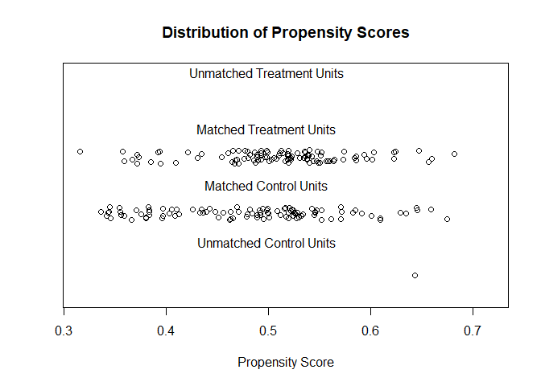

```r
emo_data <- data %>%  # MatchIt does not allow missing values
  select(id, emo, sex, income, isworking, log_age, log_city_size, TC) %>%
    na.omit()

match.emo <- matchit(emo ~ sex + income + isworking + log_age + log_city_size + TC, data = emo_data, method="nearest")

a <- summary(match.emo)

emo_data <- match.data(match.emo) %>%
  select(id, distance, weights) %>%
    left_join(data, by = c("id"))

plot(match.emo, type = 'jitter', interactive = F)
```

```r
kable(a$nn, digits = 2, align = 'c', caption = 'Table: Sample sizes')
```

Table: Sample sizes

|  | Control | Treated |
| --- | --- | --- |
| All | 105 | 104 |
| Matched | 104 | 104 |
| Unmatched | 1 | 0 |
| Discarded | 0 | 0 |

```r
t <- c("sex","income","isworking","log_age","log_city_size","TC")
t <- lapply(t, function(v) {
  #t.test(emo_data[, v] ~ emo_data[, "rat"])
  w<-wilcox.test(emo_data[, v] ~ emo_data[, "emo"], paired = F, alternative = "two.sided")
  w$p.value
})
t<-unlist(t)

#Wilcoxon rank sum test with continuity correction
#W = 4459, p-value = 0.2775
#alternative hypothesis: true location shift is not equal to 0

a <- cbind(a$sum.matched[-1,c(1,2,4)], t)
names(a)[4]<-"p-value"


kable(a, digits = 3, align = 'c',
      caption = 'Table: Summary of balance for matched data')
```

Table: Summary of balance for matched data

|  | Means Treated | Means Control | Mean Diff | p-value |
| --- | --- | --- | --- | --- |
| sex | 0.279 | 0.385 | -0.106 | 0.106 |
| income | 2.567 | 2.308 | 0.260 | 0.172 |
| isworking | 0.683 | 0.625 | 0.058 | 0.384 |
| log_age | 1.441 | 1.428 | 0.013 | 0.480 |
| log_city_size | 6.095 | 6.081 | 0.013 | 0.532 |
| TC | 0.700 | 0.693 | 0.007 | 0.793 |

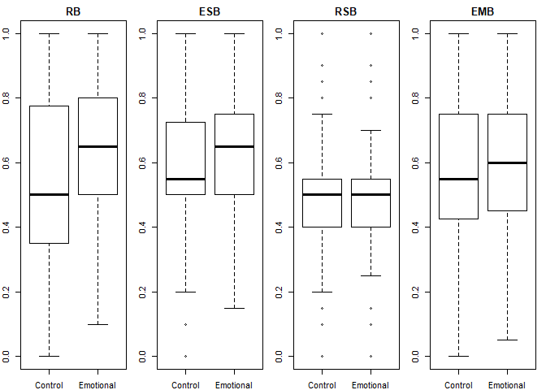

```r
by<-factor(emo_data$emo, labels = c("Control","Emotional"))

par(mfrow = c(1,4), mar=c(2,2,2,1))
boxplot(RB ~ by, data=emo_data, main="RB", horizontal = F)
boxplot(ESB ~ by, data=emo_data, main="ESB", horizontal = F)
boxplot(RSB ~ by, data=emo_data, main="RSB", horizontal = F)
boxplot(EMB ~ by, data=emo_data, main="EMB", horizontal = F)
```

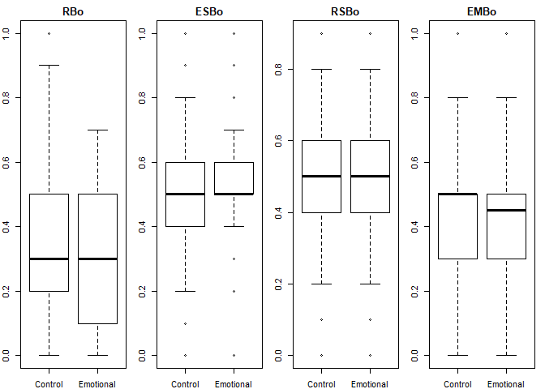

```r
boxplot(RBo ~ by, data=emo_data, main="RBo", horizontal = F)
boxplot(ESBo ~ by, data=emo_data, main="ESBo", horizontal = F)
boxplot(RSBo ~ by, data=emo_data, main="RSBo", horizontal = F)
boxplot(EMBo ~ by, data=emo_data, main="EMBo", horizontal = F)
```

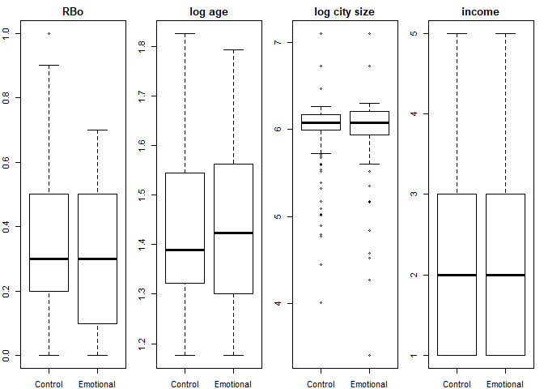

```r
boxplot(RBo ~ by, data=emo_data, main="RBo", horizontal = F)

boxplot(log_age ~ by, data=emo_data, main="log age", horizontal = F)
boxplot(log_city_size ~ by, data=emo_data, main="log city size", horizontal = F)
boxplot(income ~ by, data=emo_data, main="income", horizontal = F)
```

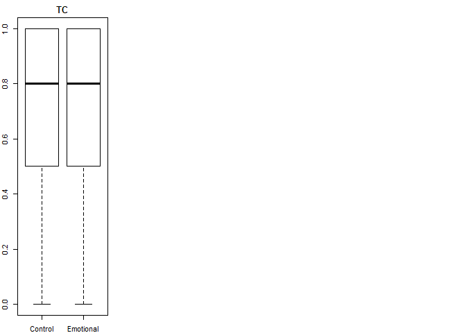

```r
boxplot(TC ~ by, data=emo_data, main="TC", horizontal = F)
```

```r
summary(emo_data[emo_data$emo==1,c(34:37,41)])
```

```
##       sex              age            income        isworking
##  Min.   :0.0000   Min.   :15.00   Min.   :1.000   Min.   :0.0000
##  1st Qu.:0.0000   1st Qu.:20.00   1st Qu.:1.000   1st Qu.:0.0000
##  Median :0.0000   Median :26.50   Median :2.000   Median :1.0000
##  Mean   :0.2788   Mean   :29.38   Mean   :2.567   Mean   :0.6827
##  3rd Qu.:1.0000   3rd Qu.:36.25   3rd Qu.:3.000   3rd Qu.:1.0000
##  Max.   :1.0000   Max.   :62.00   Max.   :5.000   Max.   :1.0000
##    city_size
##  Min.   :    2552
##  1st Qu.:  944783
##  Median : 1195446
##  Mean   : 2761433
##  3rd Qu.: 1618039
##  Max.   :12692466
```

```r
summary(emo_data[emo_data$emo==0,c(34:37,41)])
```

```
##       sex              age            income        isworking
##  Min.   :0.0000   Min.   :15.00   Min.   :1.000   Min.   :0.000
##  1st Qu.:0.0000   1st Qu.:21.00   1st Qu.:1.000   1st Qu.:0.000
##  Median :0.0000   Median :24.50   Median :2.000   Median :1.000
##  Mean   :0.3846   Mean   :28.39   Mean   :2.308   Mean   :0.625
##  3rd Qu.:1.0000   3rd Qu.:35.00   3rd Qu.:3.000   3rd Qu.:1.000
##  Max.   :1.0000   Max.   :67.00   Max.   :5.000   Max.   :1.000
##    city_size
##  Min.   :   10293
##  1st Qu.: 1020120
##  Median : 1195446
##  Mean   : 2947686
##  3rd Qu.: 1483119
##  Max.   :12692466
```

Анализ значимости различий в средних между независимыми группами (u-тест Манна-Уитни). p-value > 0.05 означает отсутствие значимых различий.

## Rational vs Control

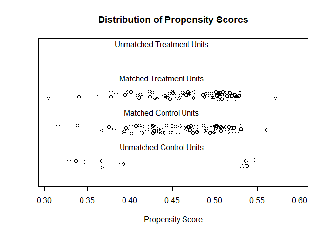

```r
rat_data <- data %>%  # MatchIt does not allow missing values
  select(id, rat, sex, income, isworking, log_age, log_city_size, TC) %>%
    na.omit()

match.rat <- matchit(rat ~ sex + income + isworking + log_age + log_city_size + TC, data = rat_data, method="nearest")

a <- summary(match.rat)

rat_data <- match.data(match.rat) %>%
  select(id, distance, weights) %>%
    left_join(data, by = c("id"))

plot(match.rat, type = 'jitter', interactive = F)
```

```r
kable(a$nn, digits = 2, align = 'c', caption = 'Table: Sample sizes')
```

Table: Sample sizes

|  | Control | Treated |
| --- | --- | --- |
| All | 105 | 91 |
| Matched | 91 | 91 |
| Unmatched | 14 | 0 |
| Discarded | 0 | 0 |

```r
t <- c("sex","income","isworking","log_age","log_city_size","TC")
t <- lapply(t, function(v) {
  #t.test(rat_data[, v] ~ rat_data[, "rat"])
  w<-wilcox.test(rat_data[, v] ~ rat_data[, "rat"], paired = F, alternative = "two.sided")
  w$p.value
})
t<-unlist(t)

#Wilcoxon rank sum test with continuity correction
#W = 4459, p-value = 0.2775
#alternative hypothesis: true location shift is not equal to 0

a <- cbind(a$sum.matched[-1,c(1,2,4)], t)
names(a)[4]<-"p-value"

kable(a, digits = 3, align = 'c',
      caption = 'Table: Summary of balance for matched data')
```

Table: Summary of balance for matched data

|  | Means Treated | Means Control | Mean Diff | p-value |
| --- | --- | --- | --- | --- |
| sex | 0.308 | 0.385 | -0.077 | 0.277 |
| income | 2.165 | 2.264 | -0.099 | 0.541 |
| isworking | 0.615 | 0.615 | 0.000 | 1.000 |
| log_age | 1.430 | 1.420 | 0.010 | 0.806 |
| log_city_size | 6.041 | 6.072 | -0.031 | 0.717 |
| TC | 0.697 | 0.682 | 0.014 | 0.689 |

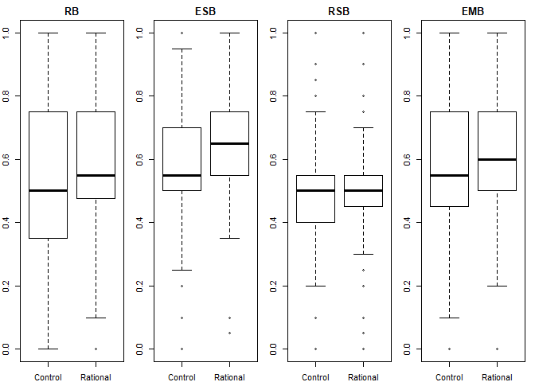

```r
by<-factor(rat_data$rat, labels = c("Control","Rational"))

par(mfrow = c(1,4), mar=c(2,2,2,1))
boxplot(RB ~ by, data=rat_data, main="RB", horizontal = F)
boxplot(ESB ~ by, data=rat_data, main="ESB", horizontal = F)
boxplot(RSB ~ by, data=rat_data, main="RSB", horizontal = F)
boxplot(EMB ~ by, data=rat_data, main="EMB", horizontal = F)
```

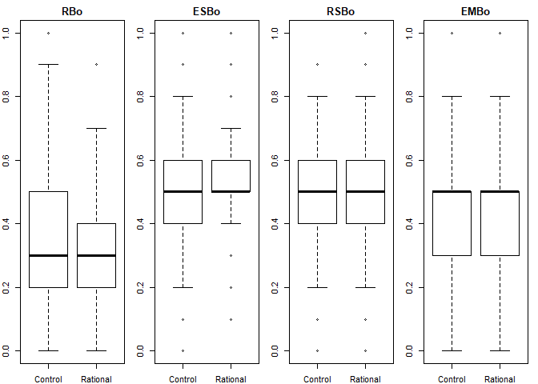

```r
boxplot(RBo ~ by, data=rat_data, main="RBo", horizontal = F)
boxplot(ESBo ~ by, data=rat_data, main="ESBo", horizontal = F)
boxplot(RSBo ~ by, data=rat_data, main="RSBo", horizontal = F)
boxplot(EMBo ~ by, data=rat_data, main="EMBo", horizontal = F)
```

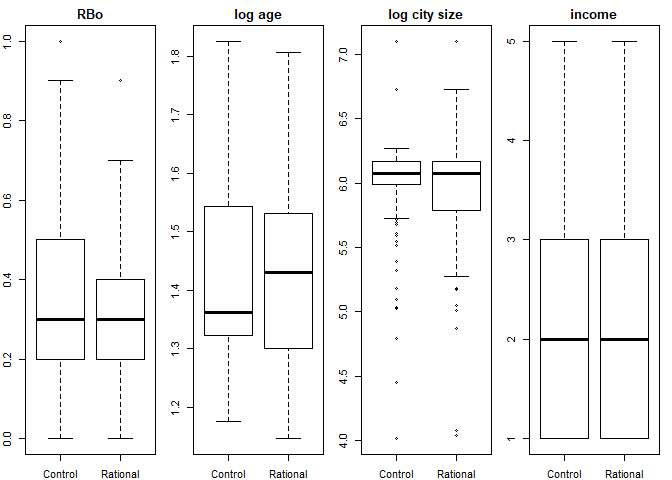

```r
boxplot(RBo ~ by, data=rat_data, main="RBo", horizontal = F)

boxplot(log_age ~ by, data=rat_data, main="log age", horizontal = F)
boxplot(log_city_size ~ by, data=rat_data, main="log city size", horizontal = F)
boxplot(income ~ by, data=rat_data, main="income", horizontal = F)
```

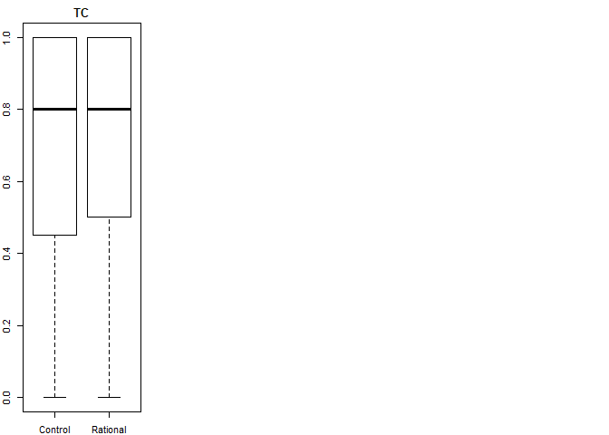

```r
boxplot(TC ~ by, data=rat_data, main="TC", horizontal = F)
```

```r
summary(rat_data[rat_data$rat==1,c(34:37,41)])
```

```
##       sex              age            income        isworking
##  Min.   :0.0000   Min.   :14.00   Min.   :1.000   Min.   :0.0000
##  1st Qu.:0.0000   1st Qu.:20.00   1st Qu.:1.000   1st Qu.:0.0000
##  Median :0.0000   Median :27.00   Median :2.000   Median :1.0000
##  Mean   :0.3077   Mean   :28.87   Mean   :2.165   Mean   :0.6154
##  3rd Qu.:1.0000   3rd Qu.:34.00   3rd Qu.:3.000   3rd Qu.:1.0000
##  Max.   :1.0000   Max.   :64.00   Max.   :5.000   Max.   :1.0000
##    city_size
##  Min.   :   10854
##  1st Qu.:  611261
##  Median : 1195446
##  Mean   : 2405108
##  3rd Qu.: 1483119
##  Max.   :12692466
```

```r
summary(rat_data[rat_data$rat==0,c(34:37,41)])
```

```
##       sex              age            income        isworking
##  Min.   :0.0000   Min.   :15.00   Min.   :1.000   Min.   :0.0000
##  1st Qu.:0.0000   1st Qu.:21.00   1st Qu.:1.000   1st Qu.:0.0000
##  Median :0.0000   Median :23.00   Median :2.000   Median :1.0000
##  Mean   :0.3846   Mean   :27.88   Mean   :2.264   Mean   :0.6154
##  3rd Qu.:1.0000   3rd Qu.:35.00   3rd Qu.:3.000   3rd Qu.:1.0000
##  Max.   :1.0000   Max.   :67.00   Max.   :5.000   Max.   :1.0000
##    city_size
##  Min.   :   10293
##  1st Qu.:  986128
##  Median : 1195446
##  Mean   : 2827260
##  3rd Qu.: 1483119
##  Max.   :12692466
```

Анализ значимости различий в средних между независимыми группами (u-тест Манна-Уитни). p-value > 0.05 означает отсутствие значимых различий.

# Результаты

## Проверка гипотезы №1

*Гипотеза H1. Эко-поведение не однородно - склонность к одному из видов эко-поведения не предопределяет склонность к другому.*

Для исследования этой гипотезы прибегнем к методу Smallest Space Analyse (SSA). В рамках данного метода в едином пространстве размещаются признаки объекта на основе некоторой метрики близости. Относительно близкие друг к другу признаки считаются однородными. Для построения пространства будем использовать метрику d=1-r, где r - коэффициент корреляции Спирмена. Двумерная диаграмма рассеяния (рис.) на основе d показывает, что чем более скоррелированы индексы склонности к некоторым видам эко-поведения, тем ближе их метки на диаграмме и, соответственно, данные виды поведения относительно более однородны.

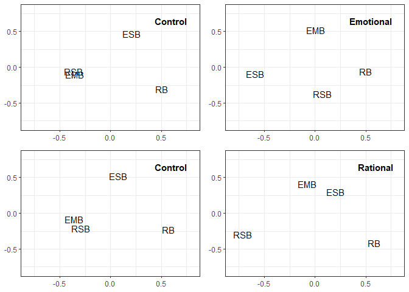

```r
#cmdscale(d, k = 2, eig = FALSE, add = FALSE, x.ret = FALSE) #Multidimensional Scaling

cols <- 56:59

ctrl_emo <- cbind(
  na.omit(emo_data[emo_data$emo==0,cols]), #na.omit
  na.omit(emo_data[emo_data$emo==1,cols])
)

names(ctrl_emo)[1:4] <- sapply(names(ctrl_emo)[1:4],function(x) paste0(x,"c"))
names(ctrl_emo)[5:8] <- sapply(names(ctrl_emo)[5:8],function(x) paste0(x,"e"))

#ctrl_emo

mds_emo <- cmdscale(as.dist(apply(cor(ctrl_emo, method = "spearman"),1:2,function(x) 1-x)), k = 2)


p0<-ggplot()+labs(x="DIM 1", y="DIM 2")+xlim(-1,1)+ylim(-1,1)+theme_bw()+
  geom_text(data=as.data.frame(mds_emo), aes(x=mds_emo[,1], y=mds_emo[,2], label=rownames(mds_emo), col="Emotional"))+
  scale_colour_manual(name="",values=c("1","2"))




d<-na.omit(emo_data[emo_data$emo==1,cols])
mds_emo <- cmdscale(as.dist(apply(cor(d, method = "spearman"),1:2,function(x) 1-x)), k = 2)

d<-na.omit(emo_data[emo_data$emo==0,cols])
mds_emo_ctrl <- cmdscale(as.dist(apply(cor(d, method = "spearman"),1:2,function(x) 1-x)), k = 2)

d<-na.omit(rat_data[rat_data$rat==1,cols])
mds_rat <- cmdscale(as.dist(apply(cor(d, method = "spearman"),1:2,function(x) 1-x)), k = 2)

d<-na.omit(rat_data[rat_data$rat==0,cols])
mds_rat_ctrl <- cmdscale(as.dist(apply(cor(d, method = "spearman"),1:2,function(x) 1-x)), k = 2)

p1<-ggplot()+labs(x="DIM 1", y="DIM 2")+xlim(-1,1)+ylim(-1,1)+theme_bw()+
  geom_text(data=as.data.frame(mds_emo), aes(x=mds_emo[,1], y=mds_emo[,2], label=rownames(mds_emo), col="Emotional"))+
  geom_text(data=as.data.frame(mds_emo_ctrl), aes(x=mds_emo_ctrl[,1], y=mds_emo_ctrl[,2], label=rownames(mds_emo_ctrl), col="Control"))+
  scale_colour_manual(name="",values=c("1","2"))

p2<-ggplot()+labs(x="DIM 1", y="DIM 2")+xlim(-1,1)+ylim(-1,1)+theme_bw()+
  geom_text(data=as.data.frame(mds_rat), aes(x=mds_rat[,1], y=mds_rat[,2], label=rownames(mds_rat), col="Rational"))+
  geom_text(data=as.data.frame(mds_rat_ctrl), aes(x=mds_rat_ctrl[,1], y=mds_rat_ctrl[,2], label=rownames(mds_rat_ctrl), col="Control"))+
  scale_colour_manual(name="",values=c("1","2"))

p0 <- ggplot()+labs(x=NULL, y=NULL)+xlim(-0.8,0.8)+ylim(-0.8,0.8)+theme_bw()
p1 <- p0 + geom_text(data=as.data.frame(mds_emo), aes(x=mds_emo[,1], y=mds_emo[,2],
                                                      label=rownames(mds_emo)))+
      #labs(title = "Emotional / Control")+
      geom_text(aes(x=0.55, y=0.65,label="Emotional"), fontface = "bold")
p2 <- p0 + geom_text(data=as.data.frame(mds_emo_ctrl), aes(x=mds_emo_ctrl[,1], y=mds_emo_ctrl[,2],
                                                      label=rownames(mds_emo_ctrl)))+
      #labs(title = "")
      geom_text(aes(x=0.6, y=0.65,label="Control"), fontface = "bold")
p3 <- p0 + geom_text(data=as.data.frame(mds_rat), aes(x=mds_rat[,1], y=mds_rat[,2],
                                                      label=rownames(mds_rat)))+
      #labs(title = "Rational / Control")
      geom_text(aes(x=0.6, y=0.65,label="Rational"), fontface = "bold")
p4 <- p0 + geom_text(data=as.data.frame(mds_rat_ctrl), aes(x=mds_rat_ctrl[,1], y=mds_rat_ctrl[,2],
                                                      label=rownames(mds_rat_ctrl)))+
      #labs(title = "")
      geom_text(aes(x=0.6, y=0.65,label="Control"), fontface = "bold")
g <- grid.arrange(p2, p1, p4, p3, ncol = 2, nrow = 2)
```

```r
#g<-arrangeGrob(p2, p1, p4, p3, ncol = 2, nrow = 2)

ggsave('H1.pdf', g)
```

На графиках можно заметить, что рассматриваемые виды эко-поведения достаточно далеки друг от друга, как в контрольной так и в экспериментальной группах, т.е. неоднородны. Эта неоднородность достаточно устойчива, воздействие стимулов не приводит к радикальным изменениям. Визуально относительно близкими можно было бы признать ресурсосбережение (RSB) и эко-мобильность (EMB) в контрольных группах, но корреляция между ними не высока ~ 0.33.

## Проверка гипотезы №2

*Гипотеза H2. Люди обычно переоценивают собственную склонность к эко-поведению и недооценивают склонность окружающих.*

Посмотрим в разрезе групп на графики плотности распределения самооцененной склонности (self) к различным видам эко-поведения и оцененной склонности окружающих (other). При построении графиков для наглядности применено сглаживание.

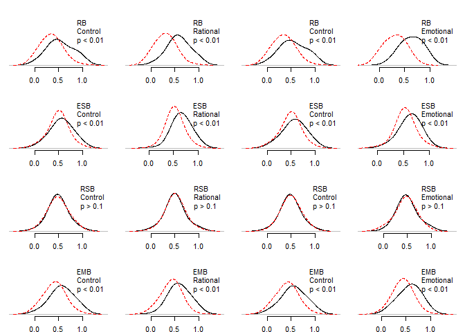

```r
dplot <- function (d, s, o, t){
  plot(density(d[,s], bw = 0.15), type = "l", col = "1", lwd = 1, bty="n", main = "",#main = paste(s,t),
       yaxt="n", ylim=c(0,2.5), xaxt="n")
  axis(side=1,at=c(0.0,0.5,1.0))
  lines(density(d[,o], bw = 0.15), lty = 2, lwd = 1, col = "2")

  #legend("topright",legend = c("self", "other"),
  #       col = c("1","2"), lwd = c(1,1),
  #       lty = c(1,2), bty = "n")

 #print(paste0(s," ", o, " ", t)) #print label for wilcox data

 #t.test(d[,s], d[,o], paired = TRUE, alternative = "two.sided") #Критерий Стьюдента
 w<-wilcox.test(d[,s], d[,o], paired = TRUE, alternative = "greater") #Критерий Уилкоксона
 legend("topright",legend = c(s, t, ifelse(w$p.value<0.01,"p < 0.01", "p > 0.1")), bty = "n")
 #w # print wilcox output
}

#RB
cols <- c(56:59,61:64)

par(mfrow = c(4,4), mar=c(1.8,1.1,1.5,1))
d<-na.omit(rat_data[rat_data$rat==0,cols])
dplot(d,"RB","RBo","Control")
d<-na.omit(rat_data[rat_data$rat==1,cols])
dplot(d,"RB","RBo","Rational")
d<-na.omit(emo_data[emo_data$emo==0,cols])
dplot(d,"RB","RBo","Control")
d<-na.omit(emo_data[emo_data$emo==1,cols])
dplot(d,"RB","RBo","Emotional")
#ESB
#par(mfrow = c(4,4), mar=c(2,2,2,1))
d<-na.omit(rat_data[rat_data$rat==0,cols])
dplot(d,"ESB","ESBo","Control")
d<-na.omit(rat_data[rat_data$rat==1,cols])
dplot(d,"ESB","ESBo","Rational")
d<-na.omit(emo_data[emo_data$emo==0,cols])
dplot(d,"ESB","ESBo","Control")
d<-na.omit(emo_data[emo_data$emo==1,cols])
dplot(d,"ESB","ESBo","Emotional")

#RSB
#par(mfrow = c(2,2), mar=c(2,2,2,1))
d<-na.omit(rat_data[rat_data$rat==0,cols])
dplot(d,"RSB","RSBo","Control")
d<-na.omit(rat_data[rat_data$rat==1,cols])
dplot(d,"RSB","RSBo","Rational")
d<-na.omit(emo_data[emo_data$emo==0,cols])
dplot(d,"RSB","RSBo","Control")
d<-na.omit(emo_data[emo_data$emo==1,cols])
dplot(d,"RSB","RSBo","Emotional")

#EMB
#par(mfrow = c(2,2), mar=c(2,2,2,1))
d<-na.omit(rat_data[rat_data$rat==0,cols])
dplot(d,"EMB","EMBo","Control")
d<-na.omit(rat_data[rat_data$rat==1,cols])
dplot(d,"EMB","EMBo","Rational")
d<-na.omit(emo_data[emo_data$emo==0,cols])
dplot(d,"EMB","EMBo","Control")
d<-na.omit(emo_data[emo_data$emo==1,cols])
dplot(d,"EMB","EMBo","Emotional")
```

```r
dopdf('H2.pdf')
```

Пунктирной линией показана оценка окружающих, сплошной - самооценка.

## Проверка гипотезы №3

*Гипотеза H3. Склонность к тому или иному виду эко-поведения ситуативно подвержена влиянию стимулов, как эмоционального, так и рационального характера.*

Для проверки этой гипотезы определим различия между средними значениями индекса склонности в контрольной и исследуемой группах по каждому виду эко-поведения. Рассмотрим различия, как в исходных (unmatched), так и в сбалансированных (matched) выборках (рис.).

По левой шкале показан индекс склонности к соответствующему виду эко-поведения, на графике среднее значение по группам. Показано p-value для одностороннего критерия Манна-Уитни.

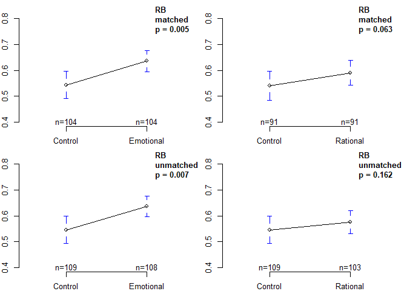

Table: RB u-тест Манна-Уитни $H_{0}: \mu_{C} < \mu_{T}$

|  | Means Control | Obs. Control | Means Treated | Obs. Treated | Means Diff | p-value |
| --- | --- | --- | --- | --- | --- | --- |
| Emotional (matched) | 0.544 | 104 | 0.636 | 104 | 0.092 | 0.005 |
| Rational (matched) | 0.541 | 91 | 0.590 | 91 | 0.049 | 0.063 |
| Emotional (unmatched) | 0.546 | 109 | 0.636 | 108 | 0.090 | 0.007 |
| Rational (unmatched) | 0.546 | 109 | 0.576 | 103 | 0.030 | 0.162 |

```r
getmeans <- function (c) {
  emo_all<-data[!is.na(data$emo),]
  rat_all<-data[!is.na(data$rat),]

  d<-rbind(
    cbind( mean(emo_data[emo_data$emo==0,c], na.rm = T),
          nrow(emo_data[emo_data$emo==0 & !is.na(emo_data[,c]),]),
          mean(emo_data[emo_data$emo==1,c], na.rm = T),
          nrow(emo_data[emo_data$emo==1 & !is.na(emo_data[,c]),]),
          with(emo_data, wilcox.test(as.formula(paste(c,"~ emo")),
                                     paired = F, alternative = "less"))$p.value),
    cbind(mean(rat_data[rat_data$rat==0,c], na.rm = T),
          nrow(rat_data[rat_data$rat==0 & !is.na(rat_data[,c]),]),
          mean(rat_data[rat_data$rat==1,c], na.rm = T),
          nrow(rat_data[rat_data$rat==1 & !is.na(rat_data[,c]),]),
          with(rat_data, wilcox.test(as.formula(paste(c,"~ rat")),
                                     paired = F, alternative = "less"))$p.value),
    cbind(mean(emo_all[emo_all$emo==0,c], na.rm = T),
          nrow(emo_all[emo_all$emo==0 & !is.na(emo_all[,c]),]),
          mean(emo_all[emo_all$emo==1,c], na.rm = T),
          nrow(emo_all[emo_all$emo==1 & !is.na(emo_all[,c]),]),
          with(emo_all, wilcox.test(as.formula(paste(c,"~ emo")),
                                     paired = F, alternative = "less"))$p.value),
    cbind(mean(rat_all[rat_all$rat==0,c], na.rm = T),
          nrow(rat_all[rat_all$rat==0 & !is.na(rat_all[,c]),]),
          mean(rat_all[rat_all$rat==1,c], na.rm = T),
          nrow(rat_all[rat_all$rat==1 & !is.na(rat_all[,c]),]),
          with(rat_all, wilcox.test(as.formula(paste(c,"~ rat")),
                                     paired = F, alternative = "less"))$p.value)
  )
  d<-cbind(d[,-5],d[,3]-d[,1],d[,5]) #reorder and add diff
  d<-data.frame(d)
  d<-cbind(c("Emotional (matched)","Rational (matched)",
             "Emotional (unmatched)", "Rational (unmatched)"),d)
  names(d) <- c("","Means Control","Obs. Control","Means Treated","Obs. Treated",
                "Means Diff","p-value")

  table <- kable(d, digits = 3, align = 'l', caption = paste('Table:',c,'u-тест Манна-Уитни $H_{0}: \\mu_{C} < \\mu_{T}$'))

  par(mfrow = c(2,2), mar=c(2,2,1.5,1))

  by<-factor(emo_data$emo, labels = c("Control","Emotional"))
  with(emo_data, plotmeans(as.formula(paste(c,"~ by")), main = "",#paste(c,"means, matched groups"),
                           frame = F, mean.labels = F, connect = T, xlab = "", ylim=c(0.4,0.8)))
  par(new=F)
  text(cex=1, font=2, x=2.1, y=0.8, xpd=T, adj=0, paste0(c,"\nmatched\np = ",round(d[1,7],3)))

  by<-factor(rat_data$rat, labels = c("Control","Rational"))
  with(rat_data, plotmeans(as.formula(paste(c,"~ by")), main = "",#paste(c,"means, matched groups"),
                           frame = F, mean.labels = F, connect = T, xlab = "", ylim=c(0.4,0.8)))
  par(new=F)
  text(cex=1, font=2, x=2.1, y=0.8, xpd=T, adj=0, paste0(c,"\nmatched\np = ",round(d[2,7],3)))



  by<-factor(emo_all$emo, labels = c("Control","Emotional"))
  with(emo_all, plotmeans(as.formula(paste(c,"~ by")), main = "",#paste(c,"means, matched groups"),
                           frame = F, mean.labels = F, connect = T, xlab = "", ylim=c(0.4,0.8)))
  par(new=F)
  text(cex=1, font=2, x=2.1, y=0.8, xpd=T, adj=0, paste0(c,"\nunmatched\np = ",round(d[3,7],3)))

  by<-factor(rat_all$rat, labels = c("Control","Rational"))
  with(rat_all, plotmeans(as.formula(paste(c,"~ by")), main = "",#paste(c,"means, matched groups"),
                           frame = F, mean.labels = F, connect = T, xlab = "", ylim=c(0.4,0.8)))
  par(new=F)
  text(cex=1, font=2, x=2.1, y=0.8, xpd=T, adj=0, paste0(c,"\nunmatched\np = ",round(d[4,7],3)))


  #with(data, plotmeans(as.formula(paste(c,"~ group")), main = "",#paste(c,"means, unmatched groups"),
  #                         frame = F, mean.labels = F, connect=F, xlab = "", ylim=c(0.4,0.8)))
  #par(new=F)
  #text(cex=1, font=2, x=2.8, y=0.8, xpd=T, adj=0, paste0(c,"\nunmatched\np = 0.00"))

  table
}
getmeans("RB")
```

```r
dopdf('H3_1.pdf')
```

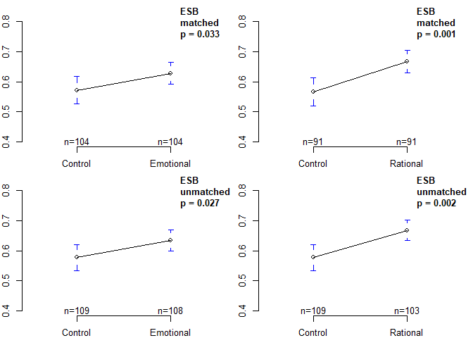

Table: ESB u-тест Манна-Уитни $H_{0}: \mu_{C} < \mu_{T}$

|  | Means Control | Obs. Control | Means Treated | Obs. Treated | Means Diff | p-value |
| --- | --- | --- | --- | --- | --- | --- |
| Emotional (matched) | 0.572 | 104 | 0.628 | 104 | 0.056 | 0.033 |
| Rational (matched) | 0.566 | 91 | 0.668 | 91 | 0.102 | 0.001 |
| Emotional (unmatched) | 0.577 | 109 | 0.634 | 108 | 0.058 | 0.027 |
| Rational (unmatched) | 0.577 | 109 | 0.667 | 103 | 0.090 | 0.002 |

```r
getmeans("ESB")
```

```r
dopdf('H3_2.pdf')
```

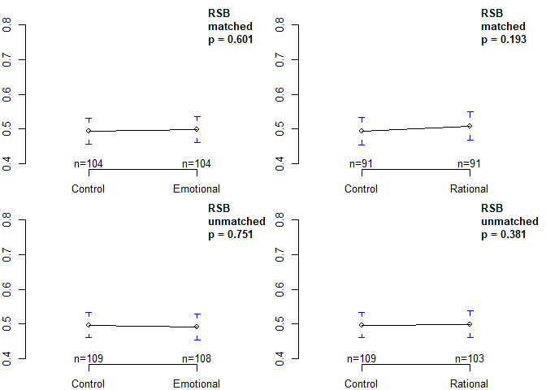

Table: RSB u-тест Манна-Уитни $H_{0}: \mu_{C} < \mu_{T}$

|  | Means Control | Obs. Control | Means Treated | Obs. Treated | Means Diff | p-value |
| --- | --- | --- | --- | --- | --- | --- |
| Emotional (matched) | 0.493 | 104 | 0.498 | 104 | 0.005 | 0.601 |
| Rational (matched) | 0.492 | 91 | 0.508 | 91 | 0.016 | 0.193 |
| Emotional (unmatched) | 0.497 | 109 | 0.492 | 108 | -0.005 | 0.751 |
| Rational (unmatched) | 0.497 | 109 | 0.499 | 103 | 0.002 | 0.381 |

```r
getmeans("RSB")
```

```r
dopdf('H3_3.pdf')
```

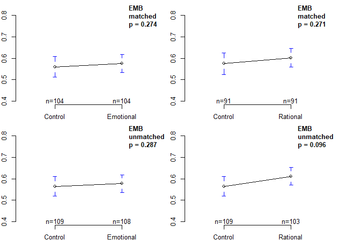

Table: EMB u-тест Манна-Уитни $H_{0}: \mu_{C} < \mu_{T}$

|  | Means Control | Obs. Control | Means Treated | Obs. Treated | Means Diff | p-value |
| --- | --- | --- | --- | --- | --- | --- |
| Emotional (matched) | 0.560 | 104 | 0.575 | 104 | 0.015 | 0.274 |
| Rational (matched) | 0.575 | 91 | 0.602 | 91 | 0.027 | 0.271 |
| Emotional (unmatched) | 0.564 | 109 | 0.577 | 108 | 0.013 | 0.287 |
| Rational (unmatched) | 0.564 | 109 | 0.612 | 103 | 0.047 | 0.096 |

```r
getmeans("EMB")
```

```r
dopdf('H3_4.pdf')
```

## Анализ роли отдельных признаков

Для этой цели построим регрессионную модель, учитывающую все интересующие признаки и контрольные переменные. Наша базовая спецификация модели выглядит следующим образом:

$Y = \beta_{0} + \beta_{1}s + \gamma X + \varepsilon$,

где $Y$ - зависимая переменная, отражающая индивидуалную оценку склонности к тому или иному виду поведения (RB, ESB, RSB, EMB) в зависимости от модели;

$s$ - бинарная независимая переменная пренадлежности к экспериментальной $(s=1)$ или контрольной группе $(s=0)$, отражающая, соответствено, эмоциональный или рациональный стимул в зависимости от модели;

$X$ - вектор контрольных переменных (пол, возраст и др.).

```r
library(lmtest)
library(sandwich)
library(DescTools)
library(car)
library(caret)
```

```r
#Функции агрегации информации о модели
fit.summary <- function (x) { #Сводная информация и базовые тесты для lm + графики
  print(summary(x)) #F-stat p < 0.05 -> good model
  #qqnorm(x$residuals)
  #qqline(x$residuals, col = 2)
  print(shapiro.test(x$residuals)) #p > 0.05 -> normal distrib
  print(bptest(x)) # studentized Breusch-Pagan test if p<0.05 -> heteroskedacity is present
  #coeftest(x) #test significance
  print(coeftest(x, vcov = vcovHC(x, "HC1")))  #robust like in Stata
  print(PseudoR2(x, which = "McFaddenAdj"))
  plot(x)
  avPlots(x)
  }

fit.plots <- function (x, v) {
  avPlots(x, as.formula(v), id=F)
  plot(x)
  }

fit.bootstrap <- function (x, r, ...) { #бутстрап
  set.seed(1313)
  mboot <- Boot(x, R = r, ...) # bootstrap samples--too small to be useful
  cbind(summary(mboot),confint(mboot))
  }

fit.coeff <- function (x, boot = F, r = 1000) { #вывод коэффициентов + бутстрап
  df<-cbind(summary(x)$coefficients[,-3],
            coeftest(x, vcov = vcovHC(x, "HC1"))[,c(-1,-3)])  #robust like in Stata
  df<-data.frame(df)
  names(df) <- c("Estimate","SE","pvalue","Robust.SE","Robust.pvalue")
  if (boot) {
    df<-cbind(df,
              fit.bootstrap(x, r)[,c(-1,-2)])
  }
  write.table(df, file = paste0('models\\',deparse(substitute(x)),'_coef.csv'), sep=";", dec=",")
  df}

fit.params <- function (x) { #вывод базовых свойств и некоторых тестов
  rname <-deparse(substitute(x))
  s<-summary(x) #F-stat p < 0.05 -> good model
  t<-shapiro.test(x$residuals) #p > 0.05 -> normal distrib
  l<-bptest(x) # studentized Breusch-Pagan test if p<0.05 -> heteroskedacity is present
  f<-PseudoR2(x, which = "McFaddenAdj")
  c<-coeftest(x, vcov = vcovHC(x, "HC1"))  #robust like in Stata
  df<-data.frame(type = as.character(s[["call"]][[1]]),
             src = as.character(s[["call"]][["data"]]),
             group = strsplit(as.character(s[["terms"]][1])," ~ ")[[3]],
             r.squared = ifelse(!is.null(s$r.squared),s$r.squared,NA),
             adj.r.squared = ifelse(!is.null(s$adj.r.squared),s$adj.r.squared,NA),
             #adj.r.pseudo = f,
             shapiro.p.value = t$p.value,
             bp.p.value = l$p.value,
             f.p.value = ifelse(!is.null(s[["fstatistic"]]),
                            pf(s[["fstatistic"]][["value"]],
                              s[["fstatistic"]][["numdf"]],
                              s[["fstatistic"]][["dendf"]], lower.tail = F), NA))#,
             #aic = ifelse(!is.null(s[["aic"]]),s[["aic"]],NA))
  if (is.null(rname))
    row.names(df)<-s[["terms"]][[2]]
      else row.names(df)<-rname
  df}
```

```r
emo_data$month <- factor(emo_data$month)
dummy <- dummyVars( ~ month, data = emo_data)
df<-predict(dummy, newdata=emo_data)
emo_data<-cbind(emo_data,df)

rat_data$month <- factor(rat_data$month)
dummy <- dummyVars( ~ month, data = rat_data)
df<-predict(dummy, newdata=rat_data)
rat_data<-cbind(rat_data,df)
```

```r
#models  RB
emo_all<-data[!is.na(data$emo),]
emo_all<-na.omit(emo_all[,c(29,32:35,45:58)])

emo_all$month <- factor(emo_all$month)
dummy <- dummyVars( ~ month, data = emo_all)
df<-predict(dummy, newdata=emo_all)
emo_all<-cbind(emo_all,df)

#whole data lm
RB_emo_m0 <- lm(RB ~ emo+sex+income+isworking+log_age+log_city_size+TC+log_time_RB+log_time_TC+
  +month.1 +month.2 +month.3 +month.4 +month.6 +month.7 +month.8 +month.9 +month.10 +month.11+month.12,
         data = emo_all, na.action=na.exclude)
#matched data lm
RB_emo_m1 <- lm(RB ~ emo+sex+income+isworking+log_age+log_city_size+TC+log_time_RB+log_time_TC+
  +month.1 +month.2 +month.3 +month.4 +month.6 +month.7 +month.8 +month.9 +month.10 +month.11+month.12,
         data = emo_data, na.action=na.exclude)
#matched data lm no controls
RB_emo_m2 <- lm(RB ~ emo, data = emo_data, na.action=na.exclude)

rat_all<-data[!is.na(data$rat),]
rat_all<-na.omit(rat_all[,c(30,32:35,45:58)])


rat_all$month <- factor(rat_all$month)
dummy <- dummyVars( ~ month, data = rat_all)
df<-predict(dummy, newdata=rat_all)
rat_all<-cbind(rat_all,df)


#whole data lm
RB_rat_m0 <- lm(RB ~ rat+sex+income+isworking+log_age+log_city_size+TC+log_time_RB+log_time_TC+
  +month.1 +month.2 +month.3 +month.4 +month.6 +month.7 +month.8 +month.9 +month.10 +month.11+month.12,
         data = rat_all, na.action=na.exclude)
#matched data lm
RB_rat_m1 <- lm(RB ~ rat+sex+income+isworking+log_age+log_city_size+TC+log_time_RB+log_time_TC+
  +month.1 +month.2 +month.3 +month.4 +month.6 +month.7 +month.8 +month.9 +month.10 +month.11+month.12,
         data = rat_data, na.action=na.exclude)
#matched data lm no controls
RB_rat_m2 <- lm(RB ~ rat, data = rat_data, na.action=na.exclude)
```

```r
#models  ESB
emo_all<-data[!is.na(data$emo),]
emo_all<-na.omit(emo_all[,c(29,32:35,45:58)])

emo_all$month <- factor(emo_all$month)
dummy <- dummyVars( ~ month, data = emo_all)
df<-predict(dummy, newdata=emo_all)
emo_all<-cbind(emo_all,df)

ESB_emo_m0 <- lm(ESB ~ emo+sex+income+isworking+log_age+log_city_size+TC+log_time_ESB+log_time_TC+
  +month.1 +month.2 +month.3 +month.4 +month.6 +month.7 +month.8 +month.9 +month.10 +month.11+month.12,
         data = emo_all, na.action=na.exclude)
#matched data lm
ESB_emo_m1 <- lm(ESB ~ emo+sex+income+isworking+log_age+log_city_size+TC+log_time_ESB+log_time_TC+
  +month.1 +month.2 +month.3 +month.4 +month.6 +month.7 +month.8 +month.9 +month.10 +month.11+month.12,
         data = emo_data, na.action=na.exclude)
ESB_emo_m2 <- lm(ESB ~ emo, data = emo_data, na.action=na.exclude)

rat_all<-data[!is.na(data$rat),]
rat_all<-na.omit(rat_all[,c(30,32:35,45:58)])


rat_all$month <- factor(rat_all$month)
dummy <- dummyVars( ~ month, data = rat_all)
df<-predict(dummy, newdata=rat_all)
rat_all<-cbind(rat_all,df)


ESB_rat_m0 <- lm(ESB ~ rat+sex+income+isworking+log_age+log_city_size+TC+log_time_ESB+log_time_TC+
  +month.1 +month.2 +month.3 +month.4 +month.6 +month.7 +month.8 +month.9 +month.10 +month.11+month.12,
         data = rat_all, na.action=na.exclude)
#matched data lm
ESB_rat_m1 <- lm(ESB ~ rat+sex+income+isworking+log_age+log_city_size+TC+log_time_ESB+log_time_TC+
  +month.1 +month.2 +month.3 +month.4 +month.6 +month.7 +month.8 +month.9 +month.10 +month.11+month.12,
         data = rat_data, na.action=na.exclude)
ESB_rat_m2 <- lm(ESB ~ rat, data = rat_data, na.action=na.exclude)
```

```r
#models  RSB
emo_all<-data[!is.na(data$emo),]
emo_all<-na.omit(emo_all[,c(29,32:35,45:58)])


emo_all$month <- factor(emo_all$month)
dummy <- dummyVars( ~ month, data = emo_all)
df<-predict(dummy, newdata=emo_all)
emo_all<-cbind(emo_all,df)

#whole data lm
RSB_emo_m0 <- lm(RSB ~ emo+sex+income+isworking+log_age+log_city_size+TC+log_time_RSB+log_time_TC+
  +month.1 +month.2 +month.3 +month.4 +month.6 +month.7 +month.8 +month.9 +month.10 +month.11+month.12,
         data = emo_all, na.action=na.exclude)
#matched data lm
RSB_emo_m1 <- lm(RSB ~ emo+sex+income+isworking+log_age+log_city_size+TC+log_time_RSB+log_time_TC+
  +month.1 +month.2 +month.3 +month.4 +month.6 +month.7 +month.8 +month.9 +month.10 +month.11+month.12,
         data = emo_data, na.action=na.exclude)
RSB_emo_m2 <- lm(RSB ~ emo, data = emo_data, na.action=na.exclude)

rat_all<-data[!is.na(data$rat),]
rat_all<-na.omit(rat_all[,c(30,32:35,45:58)])

rat_all$month <- factor(rat_all$month)
dummy <- dummyVars( ~ month, data = rat_all)
df<-predict(dummy, newdata=rat_all)
rat_all<-cbind(rat_all,df)

#whole data lm
RSB_rat_m0 <- lm(RSB ~ rat+sex+income+isworking+log_age+log_city_size+TC+log_time_RSB+log_time_TC+
  +month.1 +month.2 +month.3 +month.4 +month.6 +month.7 +month.8 +month.9 +month.10 +month.11+month.12,
         data = rat_all, na.action=na.exclude)
#matched data lm
RSB_rat_m1 <- lm(RSB ~ rat+sex+income+isworking+log_age+log_city_size+TC+log_time_RSB+log_time_TC+
  +month.1 +month.2 +month.3 +month.4 +month.6 +month.7 +month.8 +month.9 +month.10 +month.11+month.12,
         data = rat_data, na.action=na.exclude)
RSB_rat_m2 <- lm(RSB ~ rat, data = rat_data, na.action=na.exclude)
```

```r
#models  EMB
emo_all<-data[!is.na(data$emo),]
emo_all<-na.omit(emo_all[,c(29,32:35,45:58)])

emo_all$month <- factor(emo_all$month)
dummy <- dummyVars( ~ month, data = emo_all)
df<-predict(dummy, newdata=emo_all)
emo_all<-cbind(emo_all,df)

#whole data lm
EMB_emo_m0 <- lm(EMB ~ emo+sex+income+isworking+log_age+log_city_size+TC+log_time_EMB+log_time_TC+
  +month.1 +month.2 +month.3 +month.4 +month.6 +month.7 +month.8 +month.9 +month.10 +month.11+month.12,
         data = emo_all, na.action=na.exclude)
#matched data lm
EMB_emo_m1 <- lm(EMB ~ emo+sex+income+isworking+log_age+log_city_size+TC+log_time_EMB+log_time_TC+
  +month.1 +month.2 +month.3 +month.4 +month.6 +month.7 +month.8 +month.9 +month.10 +month.11+month.12,
         data = emo_data, na.action=na.exclude)
EMB_emo_m2 <- lm(EMB ~ emo, data = emo_data, na.action=na.exclude)


rat_all<-data[!is.na(data$rat),]
rat_all<-na.omit(rat_all[,c(30,32:35,45:58)])

rat_all$month <- factor(rat_all$month)
dummy <- dummyVars( ~ month, data = rat_all)
df<-predict(dummy, newdata=rat_all)
rat_all<-cbind(rat_all,df)

#whole data lm
EMB_rat_m0 <- lm(EMB ~ rat+sex+income+isworking+log_age+log_city_size+TC+log_time_EMB+log_time_TC+
  +month.1 +month.2 +month.3 +month.4 +month.6 +month.7 +month.8 +month.9 +month.10 +month.11+month.12,
         data = rat_all, na.action=na.exclude)
#matched data lm
EMB_rat_m1 <- lm(EMB ~ rat+sex+income+isworking+log_age+log_city_size+TC+log_time_EMB+log_time_TC+
  +month.1 +month.2 +month.3 +month.4 +month.6 +month.7 +month.8 +month.9 +month.10 +month.11+month.12,
         data = rat_data, na.action=na.exclude)
EMB_rat_m2 <- lm(EMB ~ rat, data = rat_data, na.action=na.exclude)
```

## Приложение

```r
#RB
fit.coeff(RB_emo_m0, boot = T)
```

```
##                   Estimate         SE      pvalue  Robust.SE Robust.pvalue
## (Intercept)    0.497066325 0.53235206 0.351641080 0.52051547  3.408227e-01
## emo            0.087720637 0.03344211 0.009425562 0.03380393  1.020176e-02
## sex           -0.030540502 0.03764273 0.418199374 0.03886556  4.329695e-01
## income        -0.047704007 0.01749416 0.006996065 0.01811843  9.166349e-03
## isworking      0.056256932 0.04500055 0.212794564 0.04395180  2.021249e-01
## log_age       -0.130356818 0.15504974 0.401554912 0.17530814  4.580499e-01
## log_city_size  0.057135414 0.02836163 0.045371086 0.02991349  5.764461e-02
## TC             0.145799949 0.05636090 0.010435670 0.06497692  2.600077e-02
## log_time_RB   -0.034335467 0.06094702 0.573853558 0.05306985  5.184258e-01
## log_time_TC    0.018898193 0.06174084 0.759873789 0.07324354  7.966733e-01
## month.1       -0.071052053 0.24025201 0.767753556 0.06074702  2.436194e-01
## month.2       -0.442218381 0.33333909 0.186231056 0.04649958  9.002827e-18
## month.3       -0.057031836 0.24027423 0.812633502 0.05349139  2.876991e-01
## month.4        0.006694217 0.27620825 0.980689834 0.12060463  9.557944e-01
## month.6        0.066139582 0.24609585 0.788411076 0.07756373  3.948979e-01
## month.7        0.072251596 0.24318865 0.766715664 0.05704280  2.068496e-01
## month.8        0.064632949 0.24541419 0.792557918 0.05757866  2.630672e-01
## month.9       -0.195945786 0.24256555 0.420218081 0.06888420  4.937232e-03
## month.10      -0.069062236 0.24120226 0.774942824 0.06164763  2.640186e-01
## month.11      -0.172426750 0.26316328 0.513130368 0.13139271  1.910102e-01
##                    bootBias     bootSE       bootMed       2.5 %      97.5 %
## (Intercept)    3.649447e-02 0.55625162  0.5539807969 -0.77128407  1.51989147
## emo           -1.492403e-03 0.03470395  0.0860343411  0.01934960  0.15580525
## sex            6.778089e-03 0.03953841 -0.0272704899 -0.10231230  0.05139121
## income        -2.958719e-05 0.01820281 -0.0472241679 -0.08612921 -0.01623385
## isworking     -5.014627e-03 0.04593885  0.0527850472 -0.04160157  0.14186982
## log_age       -6.739320e-04 0.17529107 -0.1311960757 -0.45774399  0.20964896
## log_city_size -1.111876e-03 0.03068682  0.0576587709 -0.00387525  0.11301691
## TC             2.047331e-03 0.06515511  0.1485368890  0.02151457  0.28042922
## log_time_RB    3.691607e-03 0.06128512 -0.0329864994 -0.14196831  0.10821435
## log_time_TC   -9.018098e-03 0.07945436  0.0094334605 -0.12213583  0.18816408
## month.1       -5.396975e-03 0.06407719 -0.0752897865 -0.19519057  0.05617239
## month.2        3.653397e-03 0.04941133 -0.4363613648 -0.56225289 -0.35846411
## month.3       -5.041641e-03 0.05736288 -0.0653905153 -0.15541074  0.07234285
## month.4       -1.109464e-02 0.13983100  0.0003680697 -0.29742443  0.26878923
## month.6       -2.303735e-05 0.07804256  0.0672952512 -0.09459953  0.21758199
## month.7       -4.134783e-03 0.06408520  0.0677928094 -0.05828051  0.20177854
## month.8       -2.570478e-03 0.05820089  0.0625191057 -0.05491502  0.19041337
## month.9       -8.394356e-03 0.07200573 -0.2049685632 -0.32641513 -0.01556124
## month.10      -4.499996e-03 0.06405231 -0.0756305424 -0.19330655  0.05826317
## month.11       2.913518e-03 0.14418348 -0.1725443754 -0.43367504  0.15506633
```

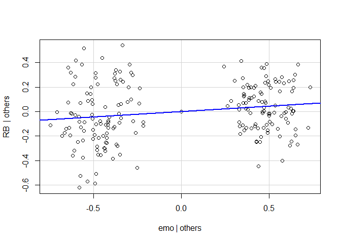

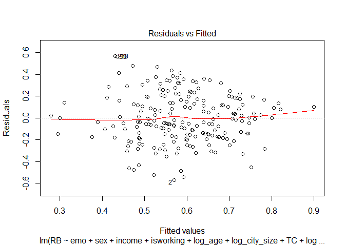

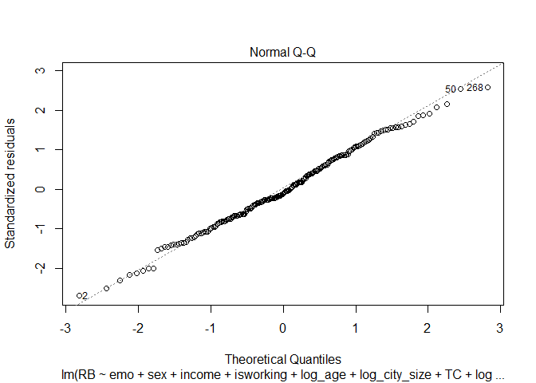

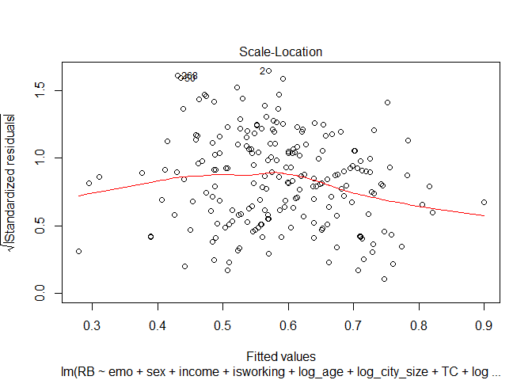

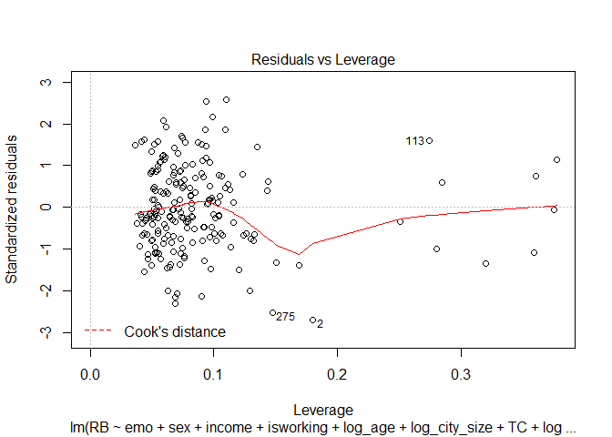

```r
fit.plots(RB_emo_m0, "~ emo")
```

```r
fit.coeff(RB_rat_m0, boot = T)
```

```
##                   Estimate         SE     pvalue  Robust.SE Robust.pvalue
## (Intercept)    0.569886142 0.58771407 0.33354385 0.48880453   0.245241540
## rat            0.038742024 0.03698480 0.29629989 0.03656070   0.290750034
## sex           -0.076339826 0.04090638 0.06367597 0.04343728   0.080575904
## income        -0.046783587 0.01929257 0.01632118 0.01930354   0.016381205
## isworking      0.055989642 0.04775468 0.24260376 0.04361001   0.200874558
## log_age        0.012342330 0.16400196 0.94009554 0.17815035   0.944845064
## log_city_size  0.058198942 0.03136318 0.06517633 0.02976111   0.052103048
## TC             0.099564836 0.05855969 0.09085439 0.06334315   0.117785339
## log_time_RB   -0.079882964 0.06664674 0.23229383 0.06071333   0.189972540
## log_time_TC    0.036107417 0.07202574 0.61677753 0.07758459   0.642224561
## month.1       -0.155667093 0.25854596 0.54789126 0.05788132   0.007846153
## month.2       -0.008103131 0.36222571 0.98217784 0.06477385   0.900588111
## month.3       -0.105748097 0.25847202 0.68294329 0.06466033   0.103744002
## month.4       -0.011027701 0.29440153 0.97016226 0.07598934   0.884780860
## month.6       -0.103181232 0.26447953 0.69691263 0.09262108   0.266791979
## month.7       -0.111854156 0.26431142 0.67267273 0.08317184   0.180402180
## month.8       -0.215498611 0.27016553 0.42614617 0.08894763   0.016416878
## month.9       -0.268979140 0.26401166 0.30968906 0.09218418   0.003984621
## month.10      -0.125659964 0.25811846 0.62698411 0.06066993   0.039798607
## month.11      -0.191560044 0.27196478 0.48214200 0.09122674   0.037170051
##                    bootBias     bootSE      bootMed       2.5 %       97.5 %
## (Intercept)    0.0248026950 0.54456789  0.573187004 -0.40399357  1.788659815
## rat           -0.0024271220 0.03747732  0.039084751 -0.04617172  0.105459253
## sex           -0.0005282826 0.04504543 -0.078557340 -0.16816856  0.009487591
## income        -0.0002996443 0.01973050 -0.047013180 -0.08634268 -0.007655166
## isworking      0.0034123835 0.04640053  0.063948279 -0.04015638  0.134993008
## log_age        0.0053070717 0.18295429  0.024111088 -0.40429911  0.352347279
## log_city_size -0.0035502366 0.03183898  0.053798856 -0.00183382  0.124765341
## TC            -0.0025788777 0.06142340  0.099706226 -0.03153885  0.220990835
## log_time_RB    0.0068447985 0.06840767 -0.069890863 -0.26227418  0.038517049
## log_time_TC   -0.0088835680 0.08024840  0.033438737 -0.14008804  0.183772564
## month.1       -0.0029893799 0.05868805 -0.157567839 -0.25582530 -0.034022269
## month.2        0.0061015087 0.06923279 -0.004205301 -0.13966333  0.130727564
## month.3        0.0004154134 0.06532554 -0.105752016 -0.22976185  0.025888142
## month.4       -0.0005319742 0.09047037 -0.021174670 -0.14601174  0.264602937
## month.6        0.0052240083 0.09918443 -0.101454239 -0.33365641  0.076492331
## month.7       -0.0069283551 0.08367696 -0.112858464 -0.28951046  0.035671942
## month.8        0.0020774703 0.09108302 -0.210211052 -0.40529946 -0.047746296
## month.9       -0.0108367553 0.10307213 -0.279367010 -0.46363007 -0.070866688
## month.10      -0.0032239630 0.06043017 -0.124640970 -0.24747715 -0.020787096
## month.11      -0.0041916547 0.10478750 -0.191092700 -0.40820475  0.018962726
```

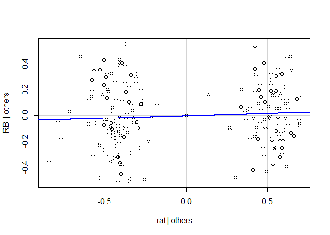

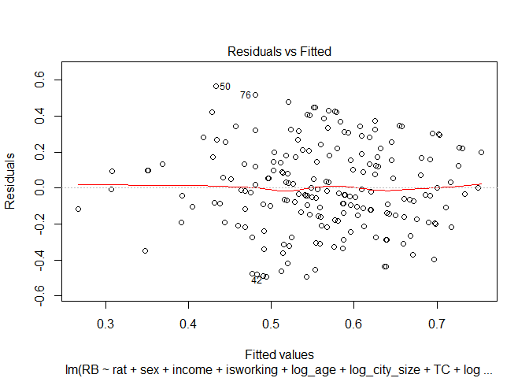

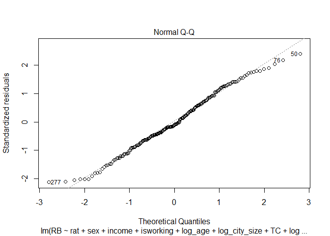

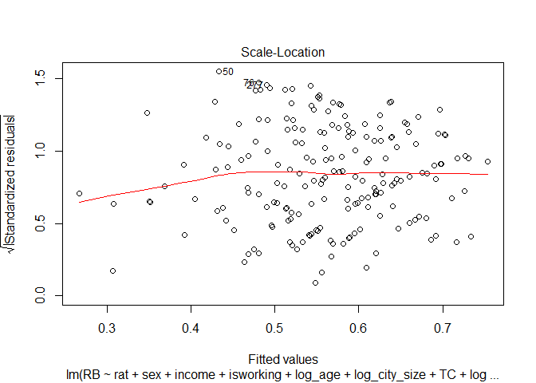

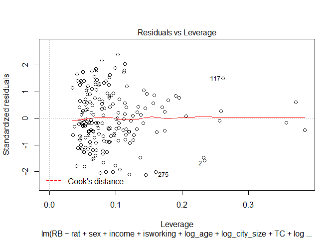

```r
fit.plots(RB_rat_m0, "~ rat")
```